# Codebook for .

Autogenerated data summary from dataReporter

2023-02-02 15:34:50

# Data report overview

The dataset examined has the following dimensions:

| Feature | Result |
| --- | --- |
| Number of observations | 5436 |
| Number of variables | 12 |

# Codebook summary table

| Label | Variable | Class | # unique values | Missing | Description |
| --- | --- | --- | --- | --- | --- |
|  | **country** | character | 2 | 0.00 % |  |
|  | **count** | numeric | 1 | 0.00 % |  |
| Region | **lives_in_specific** | character | 15 | 0.02 % |  |
| Lives In | **lives_in** | character | 3 | 0.00 % |  |
| Age | **age** | numeric | 91 | 0.07 % |  |
|  | **toothpaste** | character | 183 | 0.00 % |  |
|  | **toothpaste_full_name** | character | 605 | 0.09 % |  |
|  | **f_concentration** | integer | 48 | 6.46 % |  |
|  | **children_adult** | factor | 2 | 0.00 % |  |
| Age groups | **age_group** | factor | 4 | 0.00 % |  |
| F concentration in toothpaste | **f_concentration_group** | factor | 5 | 0.00 % |  |
|  | **f_concentration_test** | factor | 1 | 100.00 % |  |

# Variable list

## country

| Feature | Result |
| --- | --- |
| Variable type | character |
| Number of missing obs. | 0 (0 %) |
| Number of unique values | 2 |
| Mode | “Lithuania” |

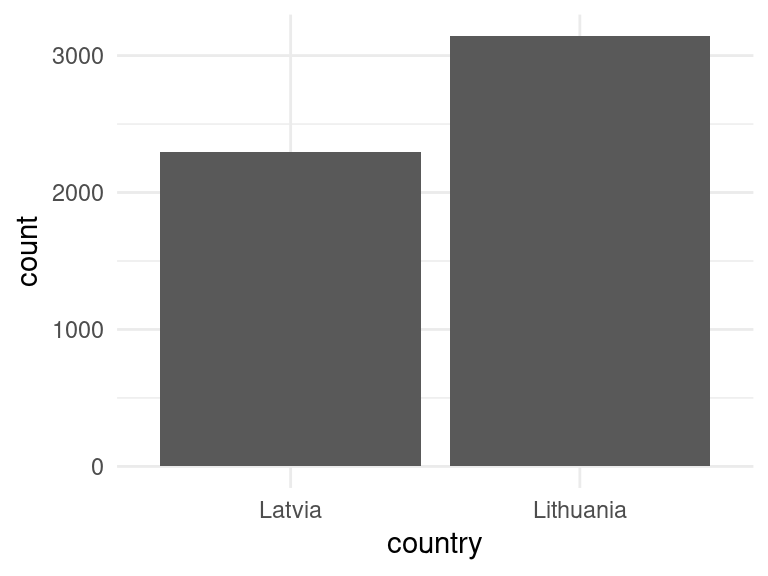

- Observed factor levels: "Latvia", "Lithuania".

## count

- The variable only takes one (non-missing) value: "1". The variable contains 0 % missing observations.

## lives_in_specific

*Region*

| Feature | Result |
| --- | --- |
| Variable type | character |
| Number of missing obs. | 1 (0.02 %) |
| Number of unique values | 14 |
| Mode | “Kaunas” |

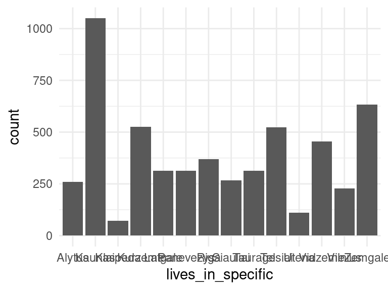

- Observed factor levels: "Alytus", "Kaunas", "Klaipeda", "Kurzeme", "Latgale", "Panevezys", "Riga", "Siauliai", "Taurage", "Telsiai", "Utena", "Vidzeme", "Vilnius", "Zemgale".

## lives_in

*Lives In*

| Feature | Result |
| --- | --- |
| Variable type | character |
| Number of missing obs. | 0 (0 %) |
| Number of unique values | 3 |
| Mode | “City” |

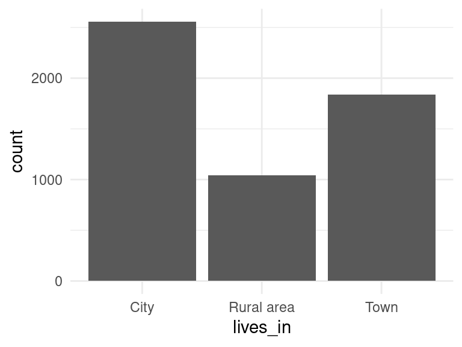

- Observed factor levels: "City", "Rural area", "Town".

## age

*Age*

| Feature | Result |
| --- | --- |
| Variable type | numeric |
| Number of missing obs. | 4 (0.07 %) |
| Number of unique values | 90 |
| Median | 26 |
| 1st and 3rd quartiles | 11; 41 |
| Min. and max. | 0; 44774 |

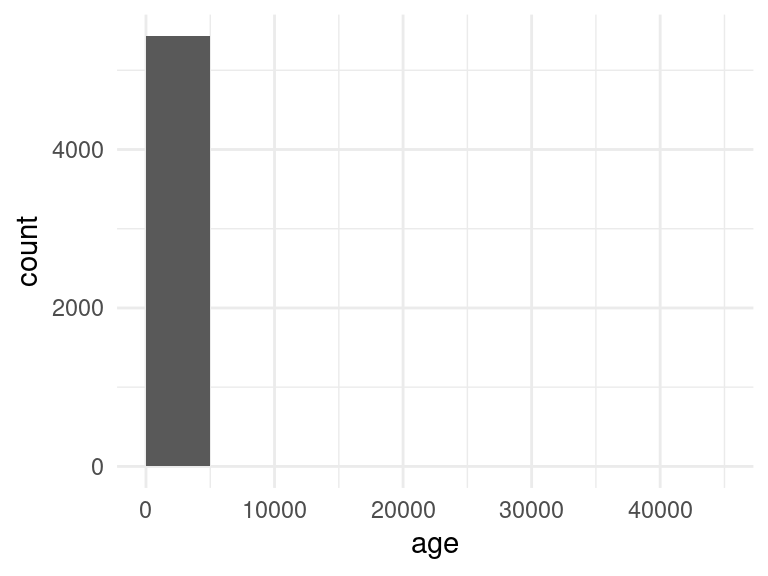

## toothpaste

| Feature | Result |
| --- | --- |
| Variable type | character |
| Number of missing obs. | 0 (0 %) |
| Number of unique values | 183 |
| Mode | “Colgate” |

[figure not shown]

- Observed factor levels: "15 sekundi", "Active KIDS Minty Fresh BEAUTY FORMULAS", "Active oral care", "Adventure Herbal", "Ajona", "Alkmene", "Alterra kids 0-6", "Apacare", "Apatite", "Aquafresh", "Arm and Hammer", "Aronal", "Atemfrisch", "Beauty Smile Whitening", "Beverly Hills Formula", "Bilka", "Bio2You", "Biomed", "BioMin", "Biominerals Mineral Herbs", "Biorepair", "BLACK “Ben and Anna”", "Black Clean balinanti su žolelėmis", "Blanx", "Blend-a-med", "Bobini", "Boots Smiles Kids", "Brush Buddies Herbal", "Buccotherm", "Casino Soin Blancheur", "Charcoal", "Chicco dentifricio", "Closeup everfresh", "Colgate", "Colodent", "Coslys", "Crest", "Curaprox", "Curasept", "Dabur RED", "Dej tu dej", "Deliplus", "Denivit", "Denta Seal", "DentaDoc", "Dentagard", "Dental tripple effect", "Dentalux", "Dentavit", "Dentesan", "Dentica", "Dentodent", "Dentofit", "Doctordent", "Donto dent Brilliant Weiss", "Dr", "Dr.organic extra whitening toothpaste", "Ecodenta", "Effa", "Elcemed", "Elgydium", "Elkos", "Elmex", "Emoform", "Eurodont", "Faberlic", "Federico mahora", "Firefly", "Fluocaril", "Fluor-Fresh", "Foramen", "Forever Bright", "Fresh & go original", "Freshmint", "FrezyDERM Sensiteeth First", "Georganics", "Glister", "Green tea tooth paste", "Greenfeel sensitive", "Gum", "Happy Moments", "Himalaya", "Humble", "ISME", "iWhite", "Jordan", "Kamro Oriental care", "Kedrov", "Kedrovij balzam", "Kin", "Kingfisher fresh", "Kokosmile", "Krievu Bio", "Kruidvat", "L’Angelica", "Lacalut", "LaLigne Dent", "Langelica", "Lebon", "Lesnoj Balsam", "Lesnoj balzam", "Lion", "Livsane", "Love, Beauty, Foods Tooth Powder", "Luneje Yunnan Baiyao Tooth", "M savers", "Malaleuca", "Marvis", "MArvita MedZahncreme Fresh Gel", "Mega Mint", "Mentadent", "Meridol", "Mirafluor", "Morrisons Savers", "N/A", "Natura Siberica", "Natural Oaceanic Peal", "Nida", "Novij zhemchug", "Nuki", "Oak Bark Modum Clasic (rusiska)", "Odol-med3", "Opalescence", "Optifresh", "Oral-B", "Oreon", "Organic people Zoom and white", "Parodontax", "Parodontol", "Pasta Del Capitano", "Pepsodent", "Periodent med", "Pierrot", "Piksters Plaque GLO", "Pomorin", "President", "Prima Fluor", "Procare", "Prokudent", "R.O.C.S.", "Rapid White", "Recepti zdorovja", "Red Seal", "Redi-Dental", "Rose Rio kids", "Royal Dent", "Saliagalen", "SensiDent", "Sensitive Daily Protection", "Sensodyne", "Signal", "SilcaMed", "SilcaPutzi", "Solidax", "Splat", "Superdrug", "Superwhite", "Svoboda", "Tebodont", "The Humble Co", "Theramed", "Todaydent", "Travjanoj balzam", "Ultradent", "Uterkam Tea Tree", "Vademecum", "Velym", "Vitex", "Vivi My", "Weleda", "Welsmile", "White Glo advantage", "WhiteWash", "WOOM", "Xoc", "Young living", "Zemciug “Blue Pearl”", "Zendium", "Zubnaja pasta otbelivanije", "Zubnaja pasta Semejnaja", "Zubnoj pasta “Propolis”", "Zubnoy dozor Apple", "Zylia".

## toothpaste_full_name

| Feature | Result |
| --- | --- |
| Variable type | character |
| Number of missing obs. | 5 (0.09 %) |
| Number of unique values | 604 |
| Mode | “Glister” |

[figure not shown]

- Observed factor levels: "15 sekundi", "Active KIDS Minty Fresh BEAUTY FORMULAS", "Active oral care (Sensitive, gentle whitening)", "Active oral care Kids Fresh & Fruity fluoride toothpaste", "active, kids", "Adventure Herbal", "Ajona Stomaticum", "Alkmene", "Alterra kids 0-6", "Apacare", "Apatite", "Aquafresh activewhite", "Aquafresh all in one", "Aquafresh Big Teeth 6-8 Years", "Aquafresh cavity prevention", "Aquafresh extra white 2x", "Aquafresh Family", "Aquafresh family protection fresh&minty", "Aquafresh Intense Clean", "Aquafresh Intensive White", "Aquafresh little teeth 3-5", "Aquafresh Mild & Minty", "Aquafresh Triple Protection", "Aquafresh Ultimate White", "Aquafresh Whitening", "Arm and Hammer Advance White Extreem", "Arm and Hammer Sensitive Care", "Aronal", "Atemfrisch", "Beauty Smile Whitening", "Beverly Hills Formula Perfect White", "Beverly Hills Formula White Black", "Bilka homeopathy 6+", "Bio2You Sensitive, Himalaya Sparkly White", "Bio2You Whitening", "Biomed Biocomplex", "Biomed Charcoal", "Biomed Propoline", "Biomed Sensitive", "Biomed Superwhite", "Biomed Ultracomplex", "BioMin", "Biominerals Mineral Herbs", "Biorepair", "Biorepair fast sensitive repair", "Biorepair Intensive Night", "Biorepair Kids", "Biorepair total protective repair", "Biorepair White", "BLACK “Ben and Anna”", "Black Clean balinanti su žolelėmis", "Blanx Sensitive", "Blanx White", "Blend-a-med (Maximum cavity protection with active fluoride)", "Blend-a-med 3D white", "Blend-a-med 3D White", "Blend-A-Med 3D White", "Blend-a-med 3D white Fresh", "Blend-a-med 3D white Luxe", "Blend-a-med Anti-cavity", "Blend-a-med Anti-cavity naturals", "Blend-a-med classic", "Blend-a-med Complete 7", "Blend-a-med Complete 7 Extra Fresh", "Blend-a-med Complete Protect expert", "Blendamed Complete protect", "Blendamed Complete protect expert", "Blendamed Complete protect fresh", "Blendamed Extra Frish", "Blendamed Extra Weiss", "Blendamed Pro expert", "Bobini dents 1-6", "Bobini junior", "Boots Smiles Kids 2-6 Spearmint", "Brush Buddies Herbal", "Buccotherm", "Buccotherm (2-6 gadi)", "Capitano Junior", "Capitano, baby +3", "Casino Soin Blancheur", "Characol Dental Nano", "charcoal", "Charcoal", "Charcoal Active", "Chicco dentifricio", "Closeup everfresh", "Colgate (Sensitive with sensifoam, whitening)", "Colgate 6-9 metu", "Colgate Advanced white", "Colgate Advanced white Charcoal", "Colgate Cavity & Enamel Protection 2-6 Years", "Colgate Cavity Protection", "Colgate cool stripe", "Colgate Fresh Confidence", "Colgate Herbal White", "Colgate Karies Kontrol", "Colgate Max White", "Colgate Max white (white and protection)", "Colgate Max white (white crystals)", "Colgate max white charcoal", "Colgate max white expert", "Colgate MAX white expert complete", "Colgate MaxFresh", "Colgate MAXIMUM cavity protection", "Colgate minions", "Colgate Natural Extracts", "Colgate natural extrects charcoal + white", "Colgate Optic White Extra Power", "Colgate Original", "Colgate Propolis", "Colgate Sensation White", "Colgate Sensation white Aktiv Kottle", "Colgate Sensitive Pro-relief", "Colgate Smiles Baby 0-2", "Colgate Smiles Junior", "Colgate Smiles kids 3-5", "Colgate strong teeth", "Colgate Toothpaste Maximum Cavity Protection Sugar Acid Neutraliser Junior ", "Colgate total", "Colgate Total", "Colgate total (Daily repair)", "Colgate total (Visible action)", "Colgate Total Deep Clean", "Colgate Total Whitening", "Colgate Triple Action", "Colgate Visible Action", "Colgate Whitening", "Colodent", "Coslys Bio gel dentifrice menthe", "Crest 3D WHITE", "Crest Anti cavity", "Crest Complete Scolp", "Crest Decay Prevention", "Curaprox Enzycal", "Curasept", "Curasept ADS 712", "Curasept biosmalto", "Curasept Biosmalto Junior", "Curasept biosmalto kids", "Curasept su F ir CHX", "Dabur RED", "Dej tu dej Ker Krasnaja Ajurvedičeskaja Zūbnaja pasta", "Deliplus Dientes Blancos", "Denivit White & Brilliant", "Denta Seal", "DentaDoc", "DentaDoc (fresh breath)", "DentaDoc (Whitening)", "DentaDoc complete care", "DentaDoc junior", "DentaDoc Junior (mint)", "DentaDoc kids 0-6", "DentaDoc mint 6+", "DentaDoc Sensitive", "DentaDoc Whitening", "Dentagard", "Dental tripple effect", "Dentalux 0-6", "Dentalux Active Charcoal", "Dentalux complex 3", "Dentalux Complex 3 Herbal Fresh", "dentalux complex 5", "Dentalux Complex 5", "Dentalux Complex 5 Sensitive Plus", "Dentalux Complex 5 Whitening plus", "Dentalux complex 7", "Dentalux Complex 7 Total Care Plus", "Dentalux Diamond Bright", "Dentalux For Kids 0-6", "Dentalux for kids 7+", "Dentalux for shining white teeth", "Dentalux x-tra fresh", "Dentalux x-tra white", "dentalux, complex 5", "dentalux, complex 7", "Dentavit pro calcium", "Dentesan Children", "Dentesan toothpaste", "Dentesan universal toothpaste", "Dentesan whitening", "Dentica kids 0-6 metai", "Dentica ultra white", "dentodent, sensitive", "Dentofit 6+", "Dentofit coolfresh", "Dentofit herbalfresh", "Doctor Dent Junior", "Doctor dent, anti-caries", "Donto dent Brilliant Weiss", "Dontodent Clear Fresh", "Dontodent kids bis 6 jahre", "Dontodent Krauter", "Dr.organic extra whitening toothpaste", "Ecodenta", "Ecodenta (with extracts of chamomile and cloves, and Kalident)", "Ecodenta 2 in 1antitartar with cranberryextr", "Ecodenta apsauga nuo karieso", "Ecodenta balinamoji su mėtų eteriniu aliejum", "Ecodenta black orange whitening", "Ecodenta black whitening", "Ecodenta bluberry nights", "Ecodenta Briliant whitening", "Ecodenta caries fighting", "Ecodenta centified organic multifunctional", "Ecodenta certified organic whitening", "Ecodenta Coconut", "Ecodenta colour surprise", "Ecodenta enamel strengthening", "Ecodenta exceptional whitening", "Ecodenta gaivi balinamoji", "Ecodenta jautriems dantims", "Ecodenta Juicy Fruit KIDS", "Ecodenta KAKE MAKE", "Ecodenta minty moisturizing", "Ecodenta multi-functional", "Ecodenta organic anti-plaque", "Ecodenta organic sensitivity relief", "Ecodenta pineapple mornings", "Ecodenta salt", "Ecodenta Sensitive whitening", "Ecodenta sensitivity relief", "Ecodenta su 7 herrb extracts and Kalident", "Ecodenta tartar eliminating", "Ecodenta triple force", "Ecodenta whitening", "Ecodenta Wild strawberry flavoured", "Elcemed Sensitive direct", "Elgydium", "Elgydium (Decay Protection)", "Elgydium (Dents Sensibles sensitive)", "Elgydium (Kids 2-6, protection caries )", "Elgydium Antiplaque", "Elgydium Ice Age", "Elgydium Junior", "Elgydium Kids 3-6 metu", "Elgydium protection caries", "Elgydium sensitive", "Elgydium whitening", "Elkos Fluor Fresh", "elmex", "Elmex", "Elmex Anti-caries professional", "Elmex anticaries", "Elmex Caries Protection", "Elmex dental enamel protection professional", "Elmex enamel professional", "Elmex intensivreinigung", "Elmex Junior", "Elmex kariesschutz", "Elmex Kids", "Elmex Kinder", "Elmex Kinder Zahnpasta (1-2 zahn)", "Elmex Sensitive", "Elmex sensitive professional", "Elmex Sensitive Whitening", "Elmex zahnsmelz", "Emoform 6+", "Emoform Kids", "Emoform-F sensitive", "Eurodont (Fresh mint)", "Eurodont 0-3", "Eurodont Mint Fresh", "eurodont, aktiv fresh", "Faberlic", "Faberlic “Ягодная мята”", "Faberlic «Кошка Клубника» 3+", "Faberlic (White plus)", "Faberlic +200% White Freeze", "Faberlic 6+", "Faberlic Astronavtik", "Faberlic ProDent", "Faberlic SENSITIVE", "Faberlic sila mineralov", "Faberlic Storie D’amore (fresh breath)", "Faberlic Total Repair", "Faberlic White Plus", "Faberlic Ежедневный уход для всей семьи Свежая мята", "faberlic, family toothpaste", "faberlic, sensitive", "Federico mahora", "Firefly anti-cavity", "FireFly LOL", "Fluocaril Blancheur", "Fluocaril Junior (6-12)", "Fluor-Fresh 3", "FluorKIN", "Foramen (Dientes Sensibles)", "Foramen charcoal toothpaste", "Forever Bright", "Fresh & go original", "Fresh and Clean Charcoal", "Freshmint", "FrezyDERM Sensiteeth First", "Georganics", "Glister", "Glister (kids)", "Green tea tooth paste", "Greenfeel sensitive", "GUM (Original White)", "Gum (Ortho)", "Gum ActiVital", "GUM ActiVital Q10", "Gum Gingidex", "Gum HaliControl", "GUM Junior", "GUM Kds", "Gum Paroex", "GUM Sensi vital", "Happy Moments (Дракоша, 1-8g)", "Himalaya ayurvedic dental cream with natural flouride", "Himalaya Botanique (Complete Care)", "Himalaya complete care", "Himalaya Dental Cream", "Himalaya Dental Cream “Salt”", "Himalaya Herbal (Stain - Away)", "Himalaya Herbal Active White", "Himalaya Herbal Healthcare Mint Fresh", "Himalaya Herbals (Complete Care)", "Himalaya Herbals (Sparkly white)", "Humble natural toothpaste strawberry", "ISME Rasyan Herbal Clove", "iWhite Instant Teeth Whitening Gum Care Toothpaste", "Iwhite, dark stains", "Jordan 0-5", "Jordan 6-12 years", "Jordan caries defence", "Jordan Cavity Protection", "Jordan Fresh Breath", "Jordan sensitive", "Jordan white smile", "Kamro Oriental care", "Kedrov", "Kedrovij balzam", "Kin B5", "Kin gingival", "Kin Ortho", "KIN progressive whitening", "Kingfisher fresh", "Koko Smile day", "Koko Smile night", "krievu bio zobu pasta", "krievu zoblu pasta, bio", "krievu zobu pasta, happy mometns", "krievu, bio", "Kruidvat ultradent 5+ Jaar", "kruidvat, ultradent, complite dental care", "kruidvat, ultradent, white", "L’Angelica Denti Sensibili", "L’Angelica Tea Tree Oil", "Lacalut (Teens 8+)", "Lacalut aktiv", "Lacalut aktiv gum protection&gentle white", "Lacalut aktiv Herbal", "Lacalut alpin", "Lacalut baby", "Lacalut basic", "Lacalut fluor", "Lacalut kids 4-8 metu", "Lacalut sensitive", "Lacalut White", "LACALUT, fluor", "LaLigne Dent Brilliant Weiss; DeniVit Anti-stain White&brilliant", "Langelica Junior", "Lebon tropical crush", "Lesnoj Balsam", "Lesnoj Balsam 7+", "Lesnoj Balsam, Colgate Max Fresh", "Lesnoj Balzam", "ļesnoj balzam", "Ļesnoj balzam", "Lesnoj Balzam (Meža Balzams)", "Lesnoj Balzam ar kumelīšu ekstraktu, kas aizsargā pret kariesu", "Lesnoj Balzam ar ozola mizu un priedes ekstraktiem", "Lion Systema Rox Mint Anti-alergic", "Lion Zact Plus", "Lion Zact Stain Fighter", "Livsane whitening", "Love, Beauty, Foods Tooth Powder", "Luneje Yunnan Baiyao Tooth", "M savers", "madaus", "Malaleuca Koala Pals Toothgel", "MARVIS", "Marvis cinnamon mint", "Marvis strong mint", "Marvis whitening mint", "MArvita MedZahncreme Fresh Gel", "Mega Mint (kids)", "Mega Mint Herbal", "Mentadent, white system", "Meridol", "Mirafluor", "Morrisons Savers", "My little Vademecum 0-6", "N/A", "Natura Siberica (Natural black whitening toothpaste)", "Natural Oaceanic Peal", "Nida Balinamoji", "Nida jautrių dantų pasta su alavijų ekstraktu", "Novij zhemchug", "Novij zhemchug dla detej", "Oak Bark Modum Clasic (rusiska)", "Odol-med3 (Extreme clean)", "odol-med3 junior zahn", "Opalescence", "Optifresh (fluoride toothpaste)", "Optifresh (system 8, Total protection)", "Optifresh kids", "Oral B Baby", "Oral B Kids", "Oral B Proexpert Stages", "Oral-B 3D white", "Oral-B complete extra white", "Oral-B Gum & Enamel", "Oreon daily care kids toothpaste", "oreon dent, whitening", "Oreondent Trio", "Organic people Zoom and white", "Paradontax fluoride", "parodontax classic", "Parodontax complete protection", "Parodontax Daily fluoride", "Parodontax extra fresh", "Parodontax Ultra clean", "Parodontax whitening", "Parodontol", "Pasta Del Capitano", "Pasta del capitano antitartaro", "Pasta del capitano curcuma & propoli", "Pasta del Capitano OX-ACTIVE Whitening", "Pasta del Capitano Protezione gengive", "Pepsodent super fluor", "Periodent med", "Pierrot +2/Piwy", "Pierrot sharky", "Piksters Plaque GLO", "Pomorin (Classic)", "President (Active)", "President (sensitive)", "President (Sensitive)", "President (Whitening toothpaste)", "President Baby 0-3", "President Junior 6+", "President Sensitive", "president, daily white", "president, junior 6+", "president, safe gums", "president, white", "Prestdent, teens", "Prima Fluor", "Procare", "Prokudent (Brillantweiss)", "Prokudent Dental Weiss", "Prokudent Frische Gel", "Prokudent Herbal", "Prokudent Junior", "Prokudent kids 0-6", "PROKUDENT Kräuter", "Prokudent sensitiv", "R.O.C.S, PRO", "R.O.C.S, teens", "R.O.C.S. (Minerals, medical with strawberries)", "R.O.C.S. (Sensation Whitening)", "R.O.C.S. bionice", "R.O.C.S. Coffee & Tabacco ", "R.O.C.S., PRO", "Rapid White", "Rapid White Anticolor", "Recepti zdorovja", "Red Seal Baking Soda", "Red Seal Kids", "Red Seal Propolis", "Red Seal Smokers", "Redi-Dental", "Rocs Brackets and Ortho Pro", "ROCS calcium", "ROCS Sensitive", "ROCS Uno Whitening", "Rose Rio Kids", "Royal Dent Gold", "Royal Dent Sensitive", "Royal Denta Jeju Citrus and Gold", "Royal denta silver", "SensiDent", "Sensitive Daily Protection Gentle Whitening", "Sensodyne Repair and Protect", "Sensodyne (Deep clean)", "Sensodyne (Fluoride)", "Sensodyne (Gentle whitening)", "Sensodyne (Gentle Whitening)", "Sensodyne (Ultraszybka ULGA)", "Sensodyne (Whitening)", "Sensodyne (Whitnening)", "Sensodyne Classic", "Sensodyne Complete", "Sensodyne daily whitening", "Sensodyne Deep Clean", "Sensodyne extra fresh", "Sensodyne Extra Whitening", "Sensodyne Fluoride", "Sensodyne fresh-mint", "Sensodyne multi-care", "Sensodyne Pronamel", "Sensodyne Pronamel 6-12", "Sensodyne Rapid Relief", "Sensodyne repair & protect", "Sensodyne sensitivity and gum whitening", "Sensodyne Ultraszybka Ulga", "Sensodyne Whitening", "Signal (Expert Protection)", "Signal (Junior)", "Signal 0-6", "Signal Anti Tartar", "Signal Junior", "Signal Kräuterfrische", "Signal White now", "Signal White Now Glossy Chic", "Signal White Now Instant Triple Power Goldi", "signal, ultra complex", "Silca Putzi", "SilcaDent MED Antitabak Coffee", "SilcaMed (Natural Extrakte) un XOC (Cleanising Charcoal)", "SilcaMed 6+ bkus kola", "Silcamed Biokalcij", "SilcaMed Family", "SilcaMed Serebro i ugolj", "Solidax", "Splat (Active)", "Splat (Medical herbs)", "Splat (Sensitive)", "Splat Baby", "Splat Biocalcium", "SPLAT Biomed Biocomplex", "SPLAT Biomed Propoline", "Splat Black Lotus", "Splat Blackwood", "Splat Extreem White", "Splat Gold", "Splat Green tea", "Splat kids", "Splat Lavendersept", "Splat mangolia", "Splat Smilex", "Splat So Natural", "Splat So Natural 6-11", "Splat Ultracomplex", "Splat White plus", "Superdrug Pro Care Sensitive Whitening", "Superdrug Sensitive Charcoal", "Superdrug Sensitive whitening Chacoal Toothpaste", "Superwhite", "Svoboda", "Tebodont", "Tebodont F", "The Humble Co", "Theramed (Original)", "Theramed Atem frisch", "Theramed Complete plus", "Theramed Junior 6+", "Theramed Naturweiß", "Theramed whitening", "Todaydent", "Todaydent frische gel", "Travjanoj balzam", "UltraDent 0-4", "Ultradent 5+", "Uterkam Tea Tree", "Vademecum (Whitening)", "Vademecum Advanced Clean", "Vademecum Junior 6+", "Vademecum Pro Vitamin Whitening", "Vademecum Pro White Complex", "Vademecum White & Fresh ", "Vademecum white and strong", "Vademecum Whitening", "Velym daily protection", "Velym lux", "Velym mineral", "Vitex Black clean", "Vivi My", "Weleda", "Weleda KinderZahngel", "Welsmile", "White Glo advantage", "Whitening tooth Polish Malaleuca", "WhiteWash", "WOOM Junior", "WOOM white", "xoc, cleansing charcoal", "Young living kidscents", "Young living Thieves", "Zemciug “Blue Pearl”", "Zendium, junior 5+", "Zubnaja pasta otbelivanije", "Zubnaja pasta Semejnaja", "Zubnoj pasta “Propolis”", "Zubnoy dozor Apple", "Zylia", "Zylia whitening", "лесной бальзам", "Лесной бальзам", "Лесной бальзам (тройной эффект)", "Лесной бальзам (укрепление зубов и десен)", "Лесной бальзам При кровоточивости десен".

## f_concentration

| Feature | Result |
| --- | --- |
| Variable type | integer |
| Number of missing obs. | 351 (6.46 %) |
| Number of unique values | 47 |
| Median | 1448 |
| 1st and 3rd quartiles | 950; 1450 |
| Min. and max. | 0; 1500 |

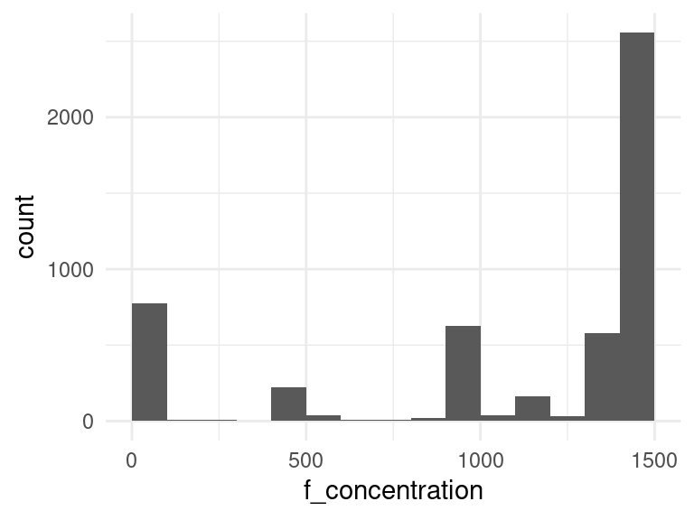

## children_adult

| Feature | Result |
| --- | --- |
| Variable type | factor |
| Number of missing obs. | 0 (0 %) |
| Number of unique values | 2 |
| Mode | “Adult toothpaste” |
| Reference category | Adult toothpaste |

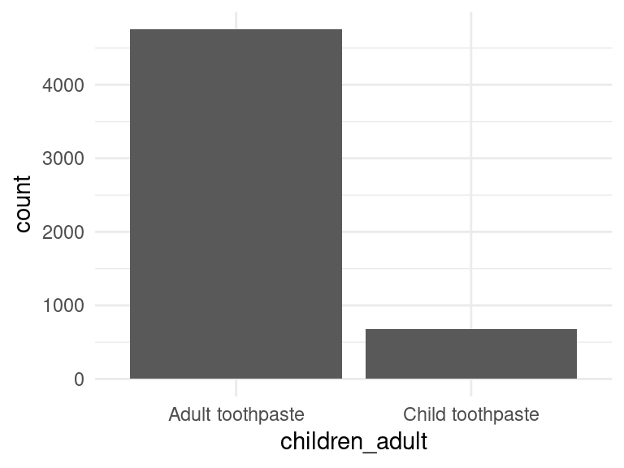

- Observed factor levels: "Adult toothpaste", "Child toothpaste".

## age_group

*Age groups*

| Feature | Result |
| --- | --- |
| Variable type | factor |
| Number of missing obs. | 0 (0 %) |
| Number of unique values | 4 |
| Mode | “> 18” |
| Reference category | 0 ~ 5 |

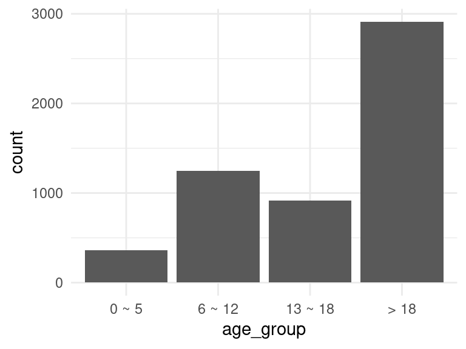

- Observed factor levels: "> 18", "0 ~ 5", "13 ~ 18", "6 ~ 12".

## f_concentration_group

*F concentration in toothpaste*

| Feature | Result |
| --- | --- |
| Variable type | factor |
| Number of missing obs. | 0 (0 %) |
| Number of unique values | 5 |
| Mode | “1400 and 1500 ppm” |
| Reference category | No fluoride |

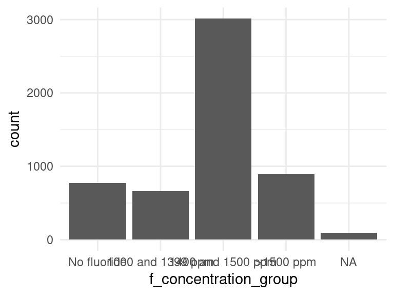

- Observed factor levels: ">1500 ppm", "1000 and 1399 ppm", "1400 and 1500 ppm", "NA", "No fluoride".

## f_concentration_test

- The variable only takes one value: "NA".

Report generation information:

- Created by: Sergio Uribe (username: `sergiouribe`).
- Report creation time: Thu Feb 02 2023 15:34:51
- Report was run from directory: `/home/sergiouribe/Dropbox/Research Ilze/2019-toothpaste-Latvia_analysis`
- dataReporter v1.0.2 [Pkg: 2021-11-11 from CRAN (R 4.1.2)]
- R version 4.1.2 (2021-11-01).
- Platform: x86_64-pc-linux-gnu (64-bit)(Pop!_OS 22.04 LTS).
- Function call: `dataReporter::makeDataReport(data = ., mode = c("summarize", "visualize", "check"), smartNum = FALSE, file = "codebook_..Rmd", checks = list(character = "showAllFactorLevels", factor = "showAllFactorLevels", labelled = "showAllFactorLevels", haven_labelled = "showAllFactorLevels", numeric = NULL, integer = NULL, logical = NULL, Date = NULL), listChecks = FALSE, maxProbVals = Inf, codebook = TRUE, reportTitle = "Codebook for .")`